# Cell-type and tissue specificity

Regina H. Reynolds

> Aim: check tissue and cell-type specificity of the colocalisations with PP H4 >= 0.75 when using p12 = 5e-6 i.e. MMRN1 and SNCA-AS1.

All external datasets used available at: https://github.com/RHReynolds/MarkerGenes

# 1 Definition of specificity

- The proportion of a gene's expression that can be attributed to one cell type or tissue within a dataset of cell types/tissues. Values range from 0 to 1, with 0 indicating a gene is not expressed at all in a cell type/tissue and 1 indicating a gene is only expressed in that cell type. If the expression of a gene is shared between two or more cell types, it will get a lower specificity measure.
- Specificity is calculated per dataset.

# 2 Tissue specificity

- Genes to investigate:

```r
genes <- c("MMRN1", "SNCA-AS1")

genes
```

```
## [1] "MMRN1"    "SNCA-AS1"
```

- Tissue specificity derived from GTEx v8.
- All tissues, apart from brain, were collapsed to an organ level.
- Also, tissues were excluded on the following criteria:
  - Less than 100 samples used.
  - Gene expression outlier e.g. testis
  - Non-natural tissue e.g. EBV-transformed lymphocytes and cultured fibroblasts.
  - Brain cortex and Brain cerebellum (using instead the more specific anterior cingulate cortex, frontal cortex and cerebellar hemisphere) to reduce redundancy across brain regions.

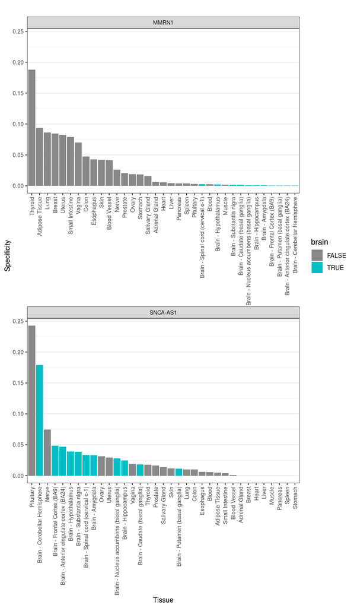

**Figure**: Specificity of MMRN1 and SNCA-AS1 in GTEx v8 tissues.

```r
# Load specificity
gtex <- readRDS(str_c(path_to_markergenes_pkg, "specificity_df/GTEx_v8.Rds"))

# Plot specificity
gtex %>%
  dplyr::filter(Description %in% genes) %>%
  dplyr::mutate(brain = case_when(str_detect(Organ, "Brain") ~ TRUE,
                                  TRUE ~ FALSE)) %>%
  ggplot(aes(x = MarkerGenes::reorder_within(x = Organ,
                                             by = specificity,
                                             within = Description,
                                             fun = median,
                                             desc = TRUE),
             y = specificity,
             fill = brain)
  ) +
  geom_col() +
  MarkerGenes::scale_x_reordered() +
  facet_wrap(vars(Description), scales = "free_x", nrow = 3) +
  labs(x = "Tissue", y = "Specificity", title = "") +
  # scale_y_continuous(limits = c(0,1)) +
  scale_fill_manual(values = c("#888888", "#00BFC4")) +
  theme_rhr
```

# 3 Cell-type specificity

- Cell-type specificity derived from a number of external datasets. All are based on single-nucleus RNA-sequencing. Notably, the AIBS dataset useds SMART-seq library construction (i.e. full-length sequencing of transcripts, as opposed to just 3'-end).

```r
# Load specificity matrices
load(str_c(path_to_markergenes_pkg, "specificity_matrices/AIBS2018_MTG.rda"))
load(str_c(path_to_markergenes_pkg, "specificity_matrices/Habib2017_DroNc_Human.rda"))
load(str_c(path_to_markergenes_pkg, "specificity_matrices/Agarwal2020_CRTX.rda"))
load(str_c(path_to_markergenes_pkg, "specificity_matrices/Agarwal2020_SNIG.rda"))
load(str_c(path_to_markergenes_pkg, "specificity_matrices/Lake2018_FrontalCortexOnly.rda"))

specificity <-
  MarkerGenes::query_gene_ctd(genes = genes,
                              ctd_AIBS2018, ctd_DRONC_human, ctd_Agarwal2020_CRTX, ctd_Agarwal2020_SNIG, ctd_BlueLake2018_FrontalCortexOnly,
                              celltypeLevel = 1,
                              median_included = F,
                              genelistSpecies = "human",
                              ctdSpecies = "human")

specificity %>%
  dplyr::distinct(Gene, Study) %>%
  dplyr::arrange(Gene)
```

| Study | Gene |
| --- | --- |
| ctd_AIBS2018 | MMRN1 |
| ctd_DRONC_human | MMRN1 |
| ctd_Agarwal2020_CRTX | MMRN1 |
| ctd_Agarwal2020_SNIG | MMRN1 |
| ctd_BlueLake2018_FrontalCortexOnly | MMRN1 |
| ctd_AIBS2018 | SNCA-AS1 |
| ctd_Agarwal2020_SNIG | SNCA-AS1 |

- Worth noting that SNCA-AS1 is only found in two human brain datasets:
  1. [ctd_AIBS2018](https://portal.brain-map.org/atlases-and-data/rnaseq/human-mtg-smart-seq): dataset includes single-nucleus transcriptomes from 15,928 nuclei derived from both frozen and neurosurgical human brain specimens, to survey cell type diversity in the human middle temporal gyrus (MTG). Nuclei from 8 human tissue donors ranging in age from 24-66 years were analyzed, revealing 75 transcriptionally distinct cell types: 45 inhibitory neuron types, 24 excitatory neuron types, and 6 non-neuronal types.
  2. [ctd_Agarwal2020_SNIG](https://www.ncbi.nlm.nih.gov/pmc/articles/PMC7442652/): dataset includes single-nucleus transcriptomes from 5943 nuclei derived from the substantia nigra of five human postmortem brains. Sequenced using the 10x Genomics Chromium platform.
- Thus, will plot MMRN1 and SNCA-AS1 specificity from these datasets.

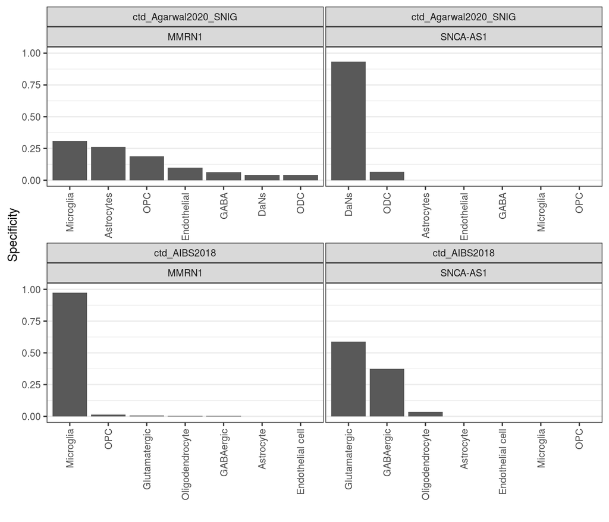

**Figure**: Plot of gene specificity value for MMRN1 and SNCA-AS1 across external RNA-seq datasets. DaNs = dopaminergic neurons; GABA=GABAergic interneurons, ODC=oligodendrocytes, OPC=oligodendrocyte precursor cells.

```r
# Plot
specificity %>%
  dplyr::filter(Study %in% c("ctd_Agarwal2020_SNIG", "ctd_AIBS2018")) %>%
  ggplot(aes(x = MarkerGenes::reorder_within(x = CellType,
                                             by = Specificity,
                                             within = Gene,
                                             fun = median,
                                             desc = T),
             y = Specificity)) +
  geom_col() +
  MarkerGenes::scale_x_reordered() +
  facet_wrap(vars(Study, Gene), scales = "free_x") +
  labs(x = "") +
  coord_cartesian(ylim = c(0,1)) +
  theme_rhr
```

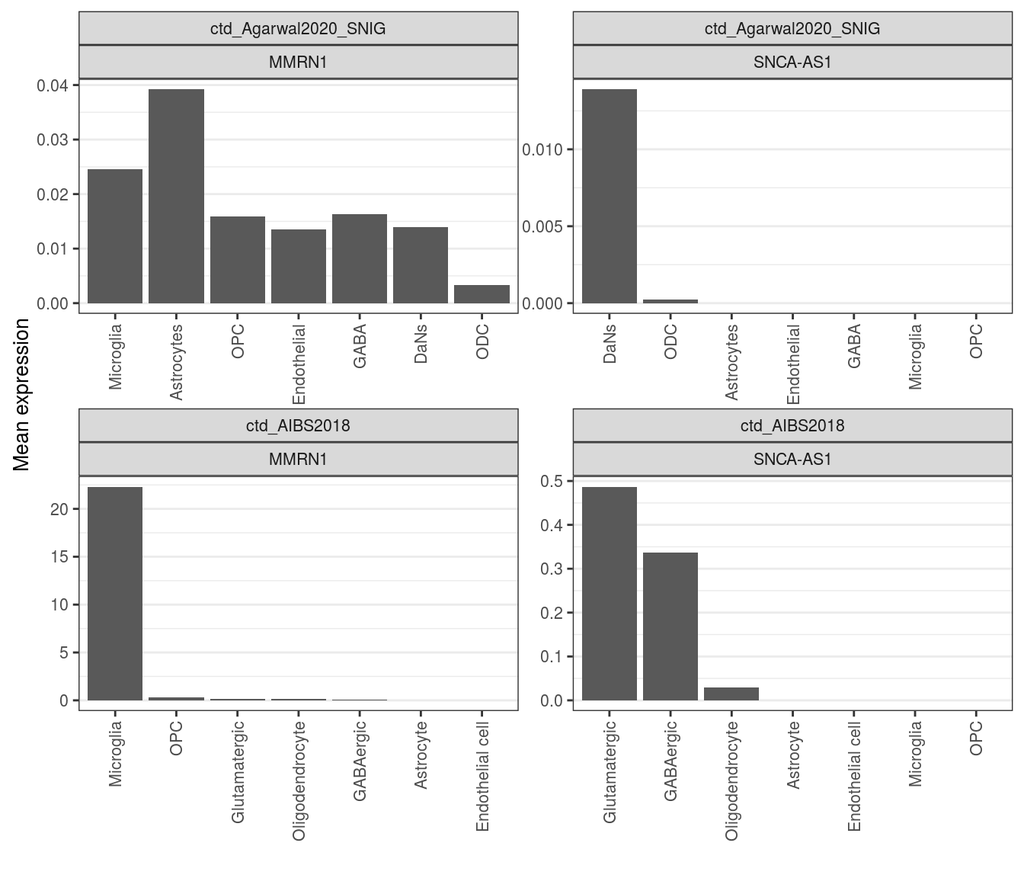

**Figure**: Plot of mean expression for MMRN1 and SNCA-AS1 across external RNA-seq datasets. Mean expression has been ordered by specificity, as in the previous plot to permit easier comparison. DaNs = dopaminergic neurons; GABA=GABAergic interneurons, ODC=oligodendrocytes, OPC=oligodendrocyte precursor cells.

```r
# Plot
specificity %>%
  dplyr::filter(Study %in% c("ctd_Agarwal2020_SNIG", "ctd_AIBS2018")) %>%
  ggplot(aes(x = MarkerGenes::reorder_within(x = CellType,
                                             by = Specificity,
                                             within = Gene,
                                             fun = median,
                                             desc = T),
             y = Mean_Expression)) +
  geom_col() +
  MarkerGenes::scale_x_reordered() +
  facet_wrap(vars(Study, Gene), scales = "free") +
  labs(x = "", y = "Mean expression") +
  theme_rhr
```

```r
specificity %>%
  dplyr::filter(Study %in% c("ctd_Agarwal2020_SNIG", "ctd_AIBS2018")) %>%
  dplyr::arrange(Gene, Study, -Specificity)
```

| Study | Study_species | Gene | CellType | Specificity | Mean_Expression |
| --- | --- | --- | --- | --- | --- |
| ctd_Agarwal2020_SNIG | human | MMRN1 | Microglia | 0.3077066639 | 0.024615385 |
| ctd_Agarwal2020_SNIG | human | MMRN1 | Astrocytes | 0.2616018646 | 0.039184953 |
| ctd_Agarwal2020_SNIG | human | MMRN1 | OPC | 0.1880491010 | 0.015873016 |
| ctd_Agarwal2020_SNIG | human | MMRN1 | Endothelial | 0.0990488930 | 0.013513514 |
| ctd_Agarwal2020_SNIG | human | MMRN1 | GABA | 0.0621166863 | 0.016260163 |
| ctd_Agarwal2020_SNIG | human | MMRN1 | DaNs | 0.0410088058 | 0.013888889 |
| ctd_Agarwal2020_SNIG | human | MMRN1 | ODC | 0.0404679562 | 0.003278689 |
| ctd_AIBS2018 | human | MMRN1 | Microglia | 0.9729516865 | 22.317460317 |
| ctd_AIBS2018 | human | MMRN1 | OPC | 0.0140212101 | 0.310924370 |
| ctd_AIBS2018 | human | MMRN1 | Glutamatergic | 0.0062546686 | 0.170071259 |

[output cut: 18 more lines]